# Analytics Edge HW7

NOTE: write up comments for all the ‘library()’ calls

```r
library(magrittr)
# library(maps) ##Note: may need to uncomment `library(maps)` for ggplot2::map_data() to work
Sys.setlocale("LC_ALL", "C")
```

```
## [1] "C"
```

```r
library(igraph) #for graph.data.frame() and degree()
library(tm) #for VCorpus() and VectorSource(), tm_map(), DocumentTermMatrix()
library(wordcloud) #for wordcloud()
library(RColorBrewer) #for display.brewer.all(), brewer.pal()
library(ggplot2) #for map_data(), all plotting functions (incl. ggplot(), geom_polygon(), geom_histogram(), scale_fill_gradient(), scale_fill_manual(), facet_grid())
```

## Election Forecasting Revisited

### Problem 1

```r
statesMap = map_data('state')
str(statesMap)
```

```
## 'data.frame':    15537 obs. of  6 variables:
##  $ long     : num  -87.5 -87.5 -87.5 -87.5 -87.6 ...
##  $ lat      : num  30.4 30.4 30.4 30.3 30.3 ...
##  $ group    : num  1 1 1 1 1 1 1 1 1 1 ...
##  $ order    : int  1 2 3 4 5 6 7 8 9 10 ...
##  $ region   : chr  "alabama" "alabama" "alabama" "alabama" ...
##  $ subregion: chr  NA NA NA NA ...
```

```r
table(statesMap$group)
```

```
##
##    1    2    3    4    5    6    7    8    9   10   11   12   13   14   15
##  202  149  312  516   79   91   94   10  872  381  233  329  257  256  113
##   16   17   18   19   20   21   22   23   24   25   26   27   28   29   30
##  397  650  399  566   36  220   30  460  370  373  382  315  238  208   70
##   31   32   33   34   35   36   37   38   39   40   41   42   43   44   45
##  125  205   78   16  290   21  168   37  733   12  105  238  284  236  172
##   46   47   48   49   50   51   52   53   54   55   56   57   58   59   60
##   66  304  166  289 1088   59  129   96   15  623   17   17   19   44  448
##   61   62   63
##  373  388   68
```

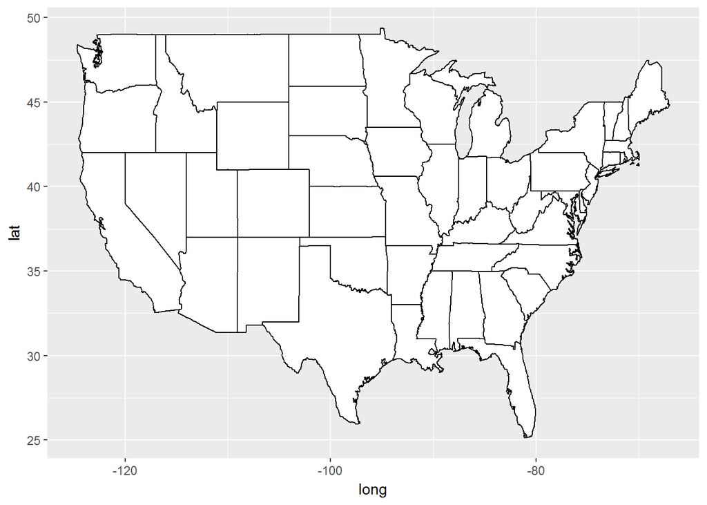

```r
ggplot(statesMap, aes(x=long, y=lat, group=group)) + geom_polygon(fill="white", color="black")
```

### Problem 2

```r
polling = read.csv('PollingImputed.csv')
str(polling)
```

```
## 'data.frame':    145 obs. of  7 variables:
##  $ State     : Factor w/ 50 levels "Alabama","Alaska",..: 1 1 2 2 3 3 3 4 4 4 ...
##  $ Year      : int  2004 2008 2004 2008 2004 2008 2012 2004 2008 2012 ...
##  $ Rasmussen : int  11 21 19 16 5 5 8 7 10 13 ...
##  $ SurveyUSA : int  18 25 21 18 15 3 5 5 7 21 ...
##  $ DiffCount : int  5 5 1 6 8 9 4 8 5 2 ...
##  $ PropR     : num  1 1 1 1 1 ...
##  $ Republican: int  1 1 1 1 1 1 1 1 1 1 ...
```

```r
train = subset(polling, Year!=2012)
test = subset(polling, Year==2012)
mod2 = glm(Republican~SurveyUSA+DiffCount, data=train, family="binomial")
TestPrediction = predict(mod2, newdata=test, type="response")
TestPredictionBinary = as.numeric(TestPrediction > 0.5)
predictionDataFrame = data.frame(TestPrediction, TestPredictionBinary, test$State)
str(predictionDataFrame)
```

```
## 'data.frame':    45 obs. of  3 variables:
##  $ TestPrediction      : num  9.74e-01 9.99e-01 9.26e-05 9.43e-03 3.43e-05 ...
##  $ TestPredictionBinary: num  1 1 0 0 0 1 1 0 1 0 ...
##  $ test.State          : Factor w/ 50 levels "Alabama","Alaska",..: 3 4 5 6 7 9 10 11 12 13 ...
```

```r
table(TestPredictionBinary)
```

```
## TestPredictionBinary
##  0  1
## 23 22
```

```r
mean(TestPrediction)
```

```
## [1] 0.4852626
```

```r
predictionDataFrame$region = tolower(predictionDataFrame$test.State)
predictionMap = merge(statesMap, predictionDataFrame, by = "region")
str(predictionMap)
```

```
## 'data.frame':    15034 obs. of  9 variables:
##  $ region              : chr  "arizona" "arizona" "arizona" "arizona" ...
##  $ long                : num  -114 -114 -114 -114 -112 ...
##  $ lat                 : num  37 37 36.8 37 37 ...
##  $ group               : num  2 2 2 2 2 2 2 2 2 2 ...
##  $ order               : int  240 241 238 239 248 249 250 251 252 253 ...
##  $ subregion           : chr  NA NA NA NA ...
##  $ TestPrediction      : num  0.974 0.974 0.974 0.974 0.974 ...
##  $ TestPredictionBinary: num  1 1 1 1 1 1 1 1 1 1 ...
##  $ test.State          : Factor w/ 50 levels "Alabama","Alaska",..: 3 3 3 3 3 3 3 3 3 3 ...
```

```r
predictionMap = predictionMap[order(predictionMap$order),] #reorder observations necessary
#for map to render properly
str(predictionMap)
```

```
## 'data.frame':    15034 obs. of  9 variables:
##  $ region              : chr  "arizona" "arizona" "arizona" "arizona" ...
##  $ long                : num  -115 -115 -115 -115 -115 ...
##  $ lat                 : num  35 35.1 35.1 35.2 35.2 ...
##  $ group               : num  2 2 2 2 2 2 2 2 2 2 ...
##  $ order               : int  204 205 206 207 208 209 210 211 212 213 ...
##  $ subregion           : chr  NA NA NA NA ...
##  $ TestPrediction      : num  0.974 0.974 0.974 0.974 0.974 ...
##  $ TestPredictionBinary: num  1 1 1 1 1 1 1 1 1 1 ...
##  $ test.State          : Factor w/ 50 levels "Alabama","Alaska",..: 3 3 3 3 3 3 3 3 3 3 ...
```

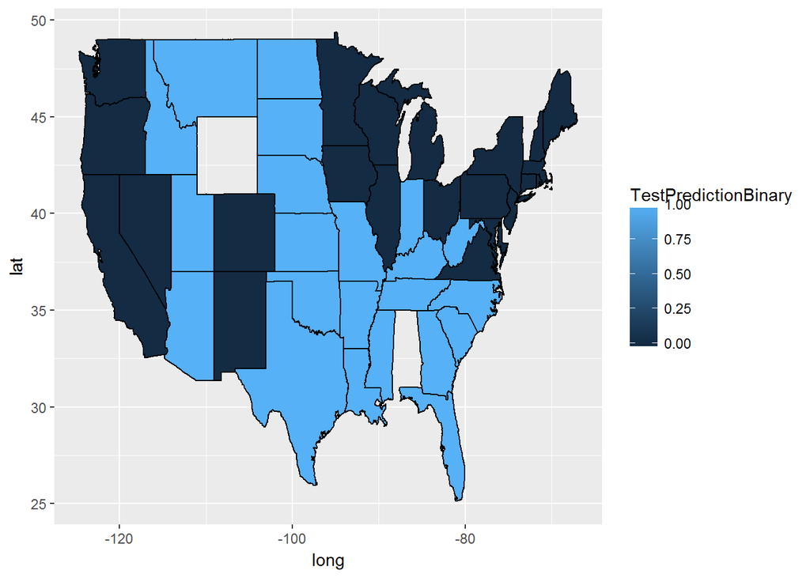

```r
ggplot(predictionMap, aes(x = long, y = lat, group = group, fill = TestPredictionBinary)) + geom_polygon(color = "black")
```

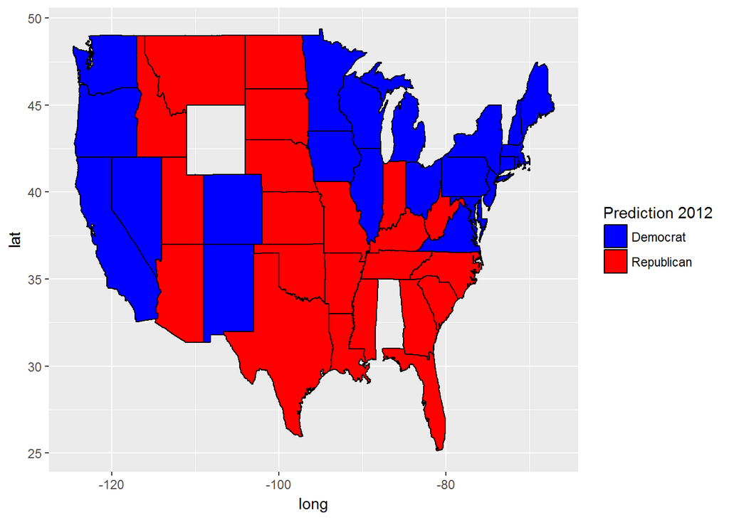

```r
ggplot(predictionMap, aes(x = long, y = lat, group = group, fill = TestPredictionBinary))+ geom_polygon(color = "black") + scale_fill_gradient(low = "blue", high = "red", guide = "legend", breaks= c(0,1), labels = c("Democrat", "Republican"), name = "Prediction 2012")
```

### Problem 3

```r
mean(subset(predictionMap,region=='florida')$TestPrediction)
```

```
## [1] 0.9640395
```

```r
str(subset(predictionMap,region=='florida'))
```

```
## 'data.frame':    872 obs. of  9 variables:
##  $ region              : chr  "florida" "florida" "florida" "florida" ...
##  $ long                : num  -85 -85 -85 -84.9 -84.9 ...
##  $ lat                 : num  31 31 30.9 30.9 30.9 ...
##  $ group               : num  9 9 9 9 9 9 9 9 9 9 ...
##  $ order               : int  1462 1463 1464 1465 1466 1467 1468 1469 1470 1471 ...
##  $ subregion           : chr  NA NA NA NA ...
##  $ TestPrediction      : num  0.964 0.964 0.964 0.964 0.964 ...
##  $ TestPredictionBinary: num  1 1 1 1 1 1 1 1 1 1 ...
##  $ test.State          : Factor w/ 50 levels "Alabama","Alaska",..: 9 9 9 9 9 9 9 9 9 9 ...
```

```r
table(subset(predictionMap,region=='florida')$TestPrediction)
```

```
##
## 0.964039495344072
##               872
```

### Problem 4

Amend ggplot cmd from problem 2 to use TestPrediction instead of TestPredictionBinary for the fill.

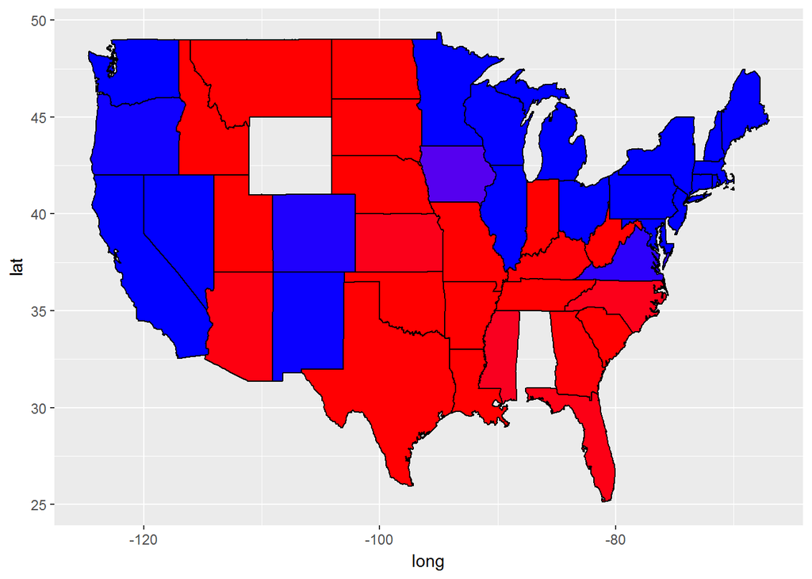

```r
ggplot(predictionMap, aes(x = long, y = lat, group = group, fill = TestPrediction))+ geom_polygon(color = "black") + scale_fill_gradient(low = "blue", high = "red", guide = "legend", breaks= c(0,1), labels = c("Democrat", "Republican"), name = "Prediction 2012")
```

To make plot 1

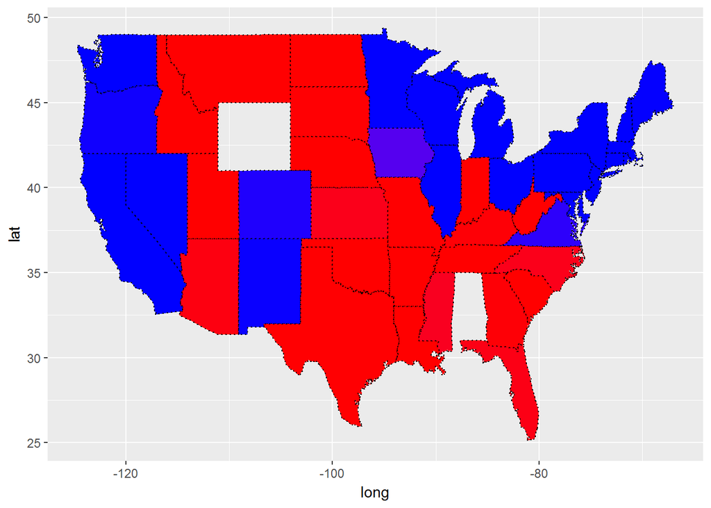

```r
ggplot(predictionMap, aes(x = long, y = lat, group = group, fill = TestPrediction))+ geom_polygon(color = "black", linetype=3) + scale_fill_gradient(low = "blue", high = "red", guide = "legend", breaks= c(0,1), labels = c("Democrat", "Republican"), name = "Prediction 2012")
```

To make plot 2

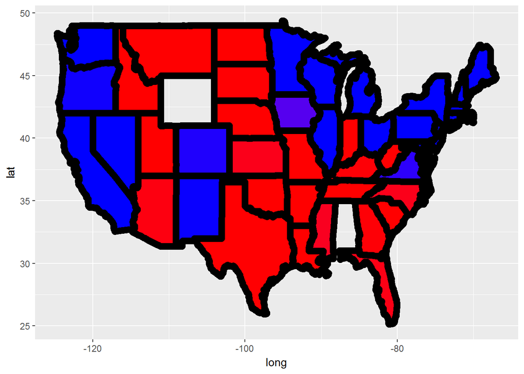

```r
ggplot(predictionMap, aes(x = long, y = lat, group = group, fill = TestPrediction))+ geom_polygon(color = "black", size=3) + scale_fill_gradient(low = "blue", high = "red", guide = "legend", breaks= c(0,1), labels = c("Democrat", "Republican"), name = "Prediction 2012")
```

to make plot 3

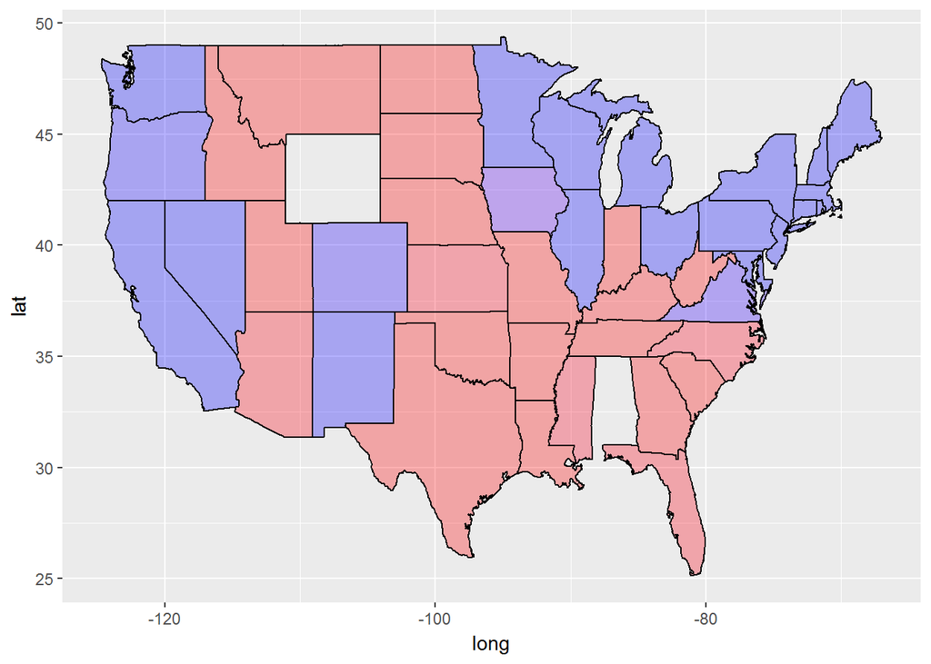

```r
ggplot(predictionMap, aes(x = long, y = lat, group = group, fill = TestPrediction))+ geom_polygon(color = "black", alpha=0.3) + scale_fill_gradient(low = "blue", high = "red", guide = "legend", breaks= c(0,1), labels = c("Democrat", "Republican"), name = "Prediction 2012")
```

## Visualizing Network Data

### Problem 1

```r
users=read.csv('users.csv')
edges=read.csv('edges.csv')
nrow(users)
```

```
## [1] 59
```

```r
head(users)
```

```
##     id gender school locale
## 1 3981      A      A      B
## 2 3982      B             B
## 3 3983      B             B
## 4 3984      B             B
## 5 3985      B             B
## 6 3986      B      A      B
```

```r
head(edges)
```

```
##     V1   V2
## 1 4019 4026
## 2 4023 4031
## 3 4023 4030
## 4 4027 4032
## 5 3988 4021
## 6 3982 3986
```

```r
users$school = as.character(users$school)
users$school = ifelse(!(users$school %in% c('A','AB')),NA,users$school)
head(users)
```

```
##     id gender school locale
## 1 3981      A      A      B
## 2 3982      B   <NA>      B
## 3 3983      B   <NA>      B
## 4 3984      B   <NA>      B
## 5 3985      B   <NA>      B
## 6 3986      B      A      B
```

```r
nonMissingSch = subset(users, !is.na(users$school))
str(nonMissingSch)
```

```
## 'data.frame':    19 obs. of  4 variables:
##  $ id    : int  3981 3986 3989 3991 3992 594 3999 4002 4005 4010 ...
##  $ gender: Factor w/ 3 levels "","A","B": 2 3 3 3 2 3 3 3 3 3 ...
##  $ school: chr  "A" "A" "A" "A" ...
##  $ locale: Factor w/ 3 levels "","A","B": 3 3 3 3 3 3 3 3 3 3 ...
```

```r
table(nonMissingSch$locale)
```

```
##
##     A  B
##  0  0 19
```

```r
table(nonMissingSch$gender, nonMissingSch$school)
```

```
##
##      A AB
##      1  0
##   A  3  1
##   B 13  1
```

### Problem 2

```r
g = graph.data.frame(d=edges, directed=FALSE, vertices=users) #note: g is instance of class igraph
```

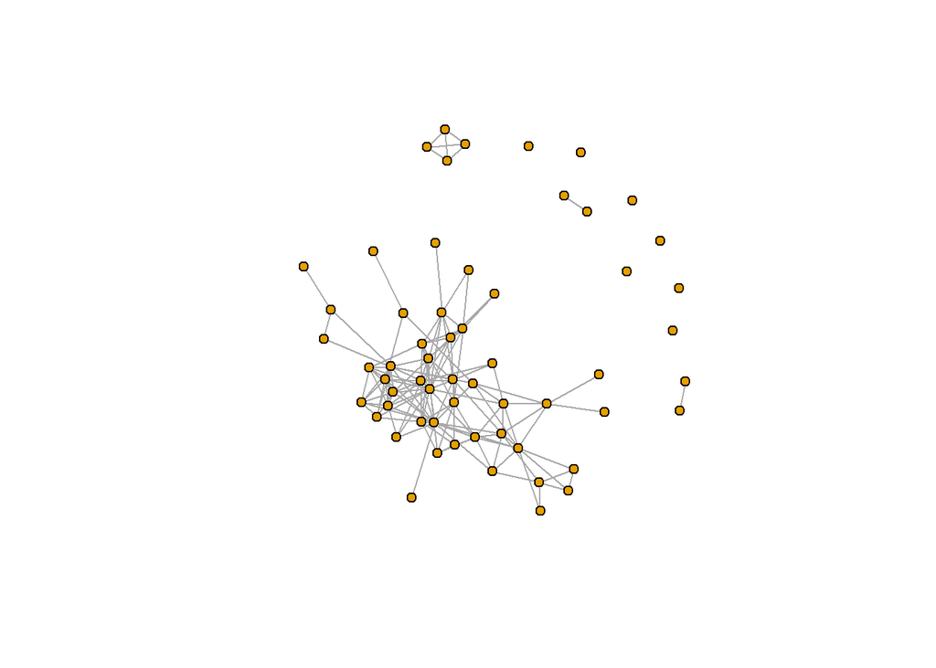

```r
plot(g, vertex.size=5, vertex.label=NA)
```

```r
degs=degree(g)
sum(degs>=10)
```

```
## [1] 9
```

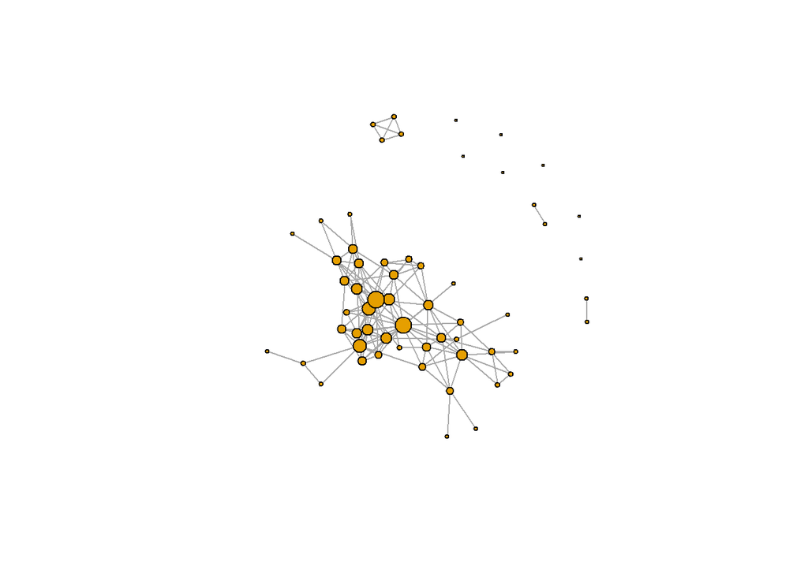

```r
V(g)$size = degree(g)/2+2 #Note: calling function V() on an igraph returns a vertex sequence (class is igraph.vs) of all vertices of a graph. We've thus set the sizes of vertices to be in proportion to their degrees.
plot(g, vertex.label=NA)
```

```r
V(g)$size%>%max
```

```
## [1] 11
```

```r
V(g)$size%>%min
```

```
## [1] 2
```

### Problem 3

Note that gender, school and locale of users are respectively stored in `V(g)$gender`, `V(g)$school` and `V(g)$locale`.

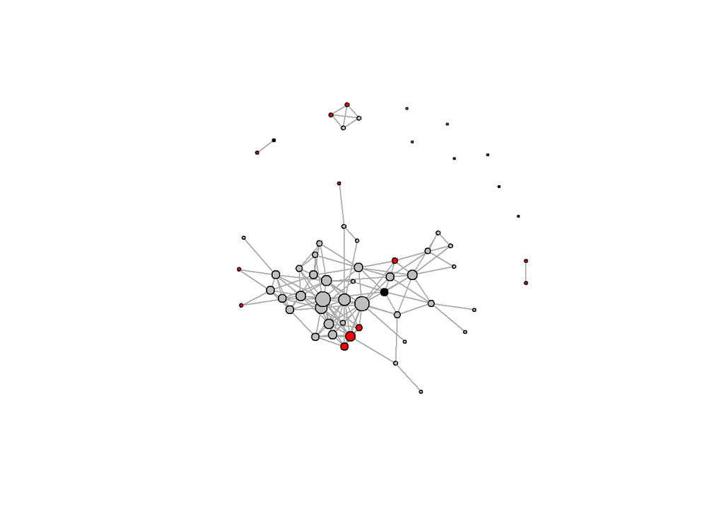

```r
V(g)$color = "black"
V(g)$color[V(g)$gender == "A"] = "red"
V(g)$color[V(g)$gender == "B"] = "gray"
plot(g, vertex.label=NA)
```

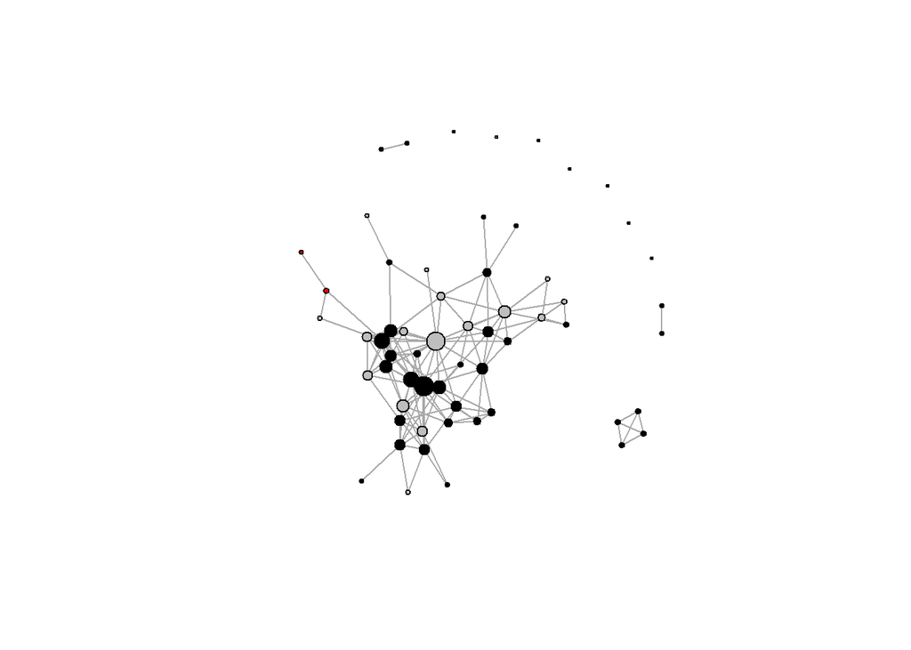

```r
V(g)$color = "black"
V(g)$color[V(g)$school == "A"] = "gray"
V(g)$color[V(g)$school == "AB"] = "red"
plot(g, vertex.label=NA)
```

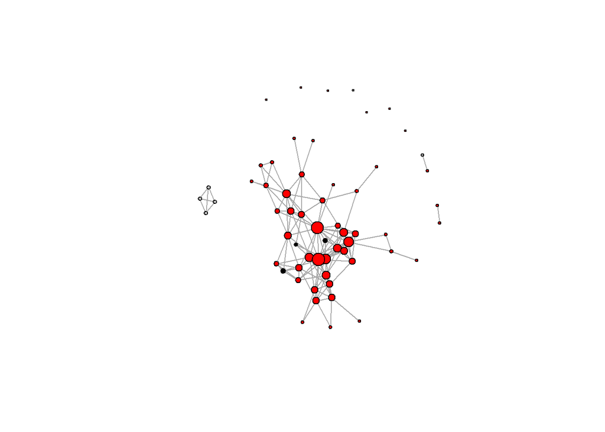

```r
V(g)$color = "black"
V(g)$color[V(g)$locale == "A"] = "gray"
V(g)$color[V(g)$locale == "B"] = "red"
plot(g, vertex.label=NA)
```

### Problem 4

No relevant code

## Visualizing Text Data Using Word Clouds

### Problem 1

```r
tweets=read.csv('tweets.csv', stringsAsFactors = F)
corpus = VCorpus(VectorSource(tweets$Tweet))
corpus = tm_map(corpus, content_transformer(tolower))
corpus = tm_map(corpus, removePunctuation)
corpus = tm_map(corpus, removeWords, stopwords('english'))
corpus
```

```
## <<VCorpus>>
## Metadata:  corpus specific: 0, document level (indexed): 0
## Content:  documents: 1181
```

```r
corpus[[1]]$content
```

```
## [1] "   say apple   far  best customer care service   ever received apple appstore"
```

```r
corpus[[2]]$content
```

```
## [1] "ios 7   fricking smooth  beautiful thanxapple apple"
```

```r
dtm=DocumentTermMatrix(corpus)
dtm
```

```
## <<DocumentTermMatrix (documents: 1181, terms: 3780)>>
## Non-/sparse entries: 10273/4453907
## Sparsity           : 100%
## Maximal term length: 115
## Weighting          : term frequency (tf)
```

```r
allTweets = as.data.frame(as.matrix(dtm))
dim(allTweets)
```

```
## [1] 1181 3780
```

### Problem 2

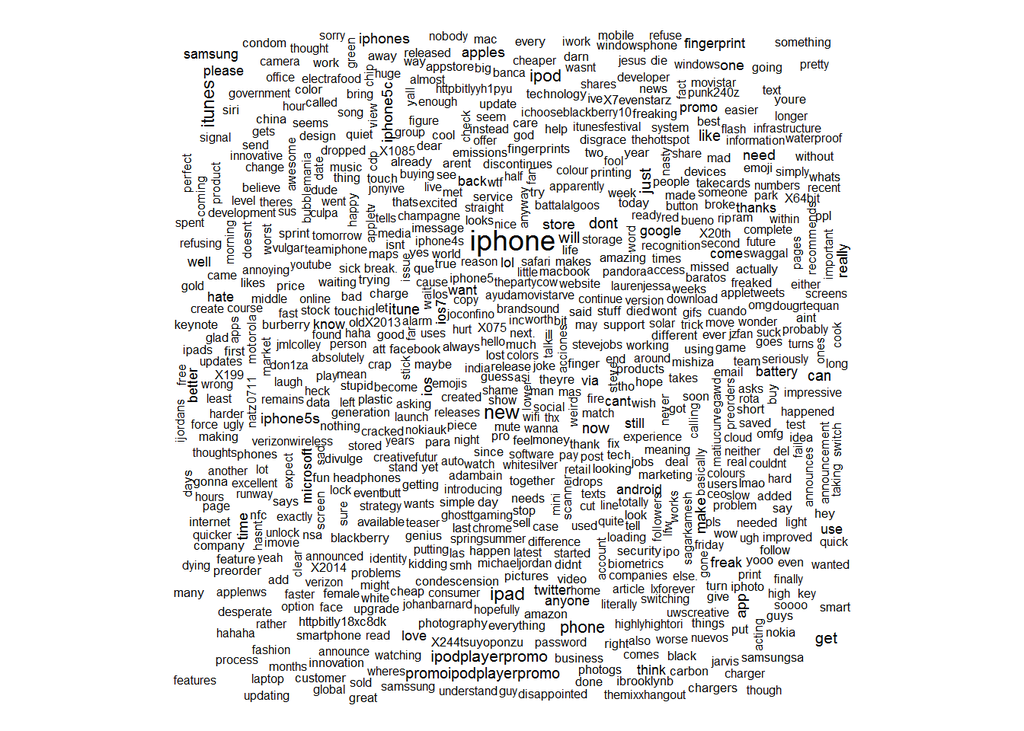

```r
words = make.names(colnames(allTweets))
freq = colSums(allTweets)
wordcloud(words=words,freq=freq)
```

Some words in the vector of words passed to the wordcloud function were not displayed due to their being unable to fit in the wordcloud. The default scale parameter is `c(4,0.5)`. Let’s try again with the scale parameter set to `c(4*0.75, 0.5*0.75)` and see if the words that weren’t displayed are now displayedd.

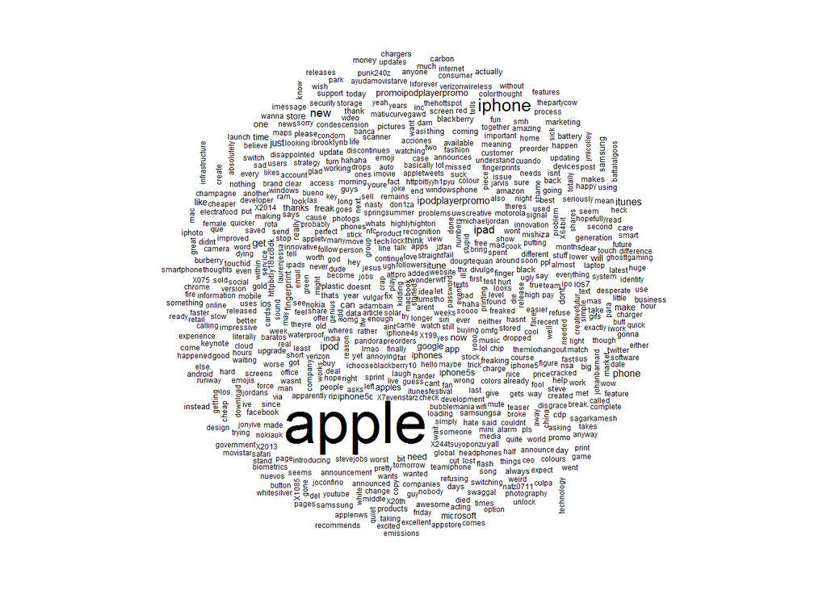

```r
wordcloud(words=words,freq=freq, scale=c(4*0.75,0.5*0.75))
```

Reducing the scale does indeed reduce the number of words that fail to be displayed in the wordcloud.

```r
mostFreq=colSums(allTweets)%>%sort()%>%tail(1)
names(mostFreq)[1]
```

```
## [1] "apple"
```

```r
names(mostFreq)[1]%>%str()
```

```
##  chr "apple"
```

```r
corpus = VCorpus(VectorSource(tweets$Tweet))
corpus = tm_map(corpus, content_transformer(tolower))
corpus = tm_map(corpus, removePunctuation)
corpus = tm_map(corpus, removeWords, c(names(mostFreq)[1],stopwords('english')))
allButMostFreq = as.data.frame(as.matrix(DocumentTermMatrix(corpus)))
dim(allButMostFreq) #compare to original w/ 3780 columns
```

```
## [1] 1181 3779
```

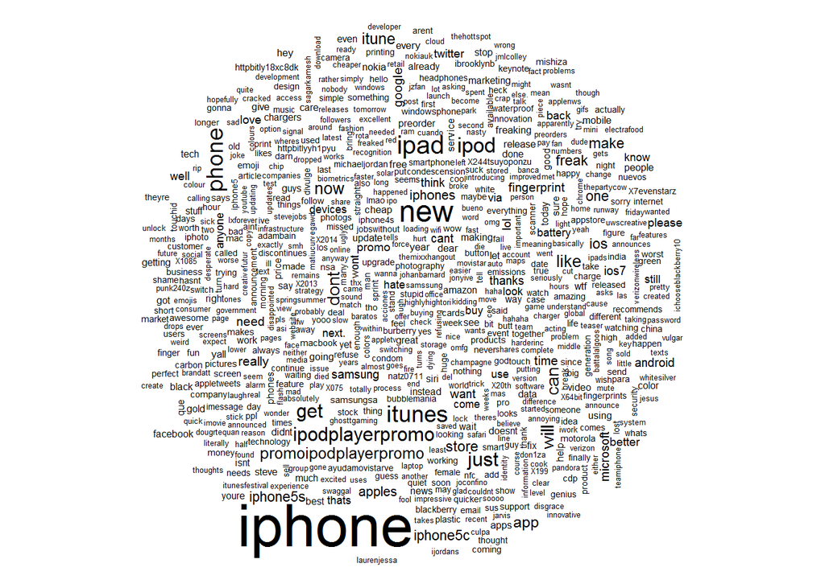

```r
words = make.names(colnames(allButMostFreq))
freq = colSums(allButMostFreq)
wordcloud(words=words, freq=freq, scale=c(4*0.75,0.5*0.75))
```

### Problem 3

Negative Tweets Only

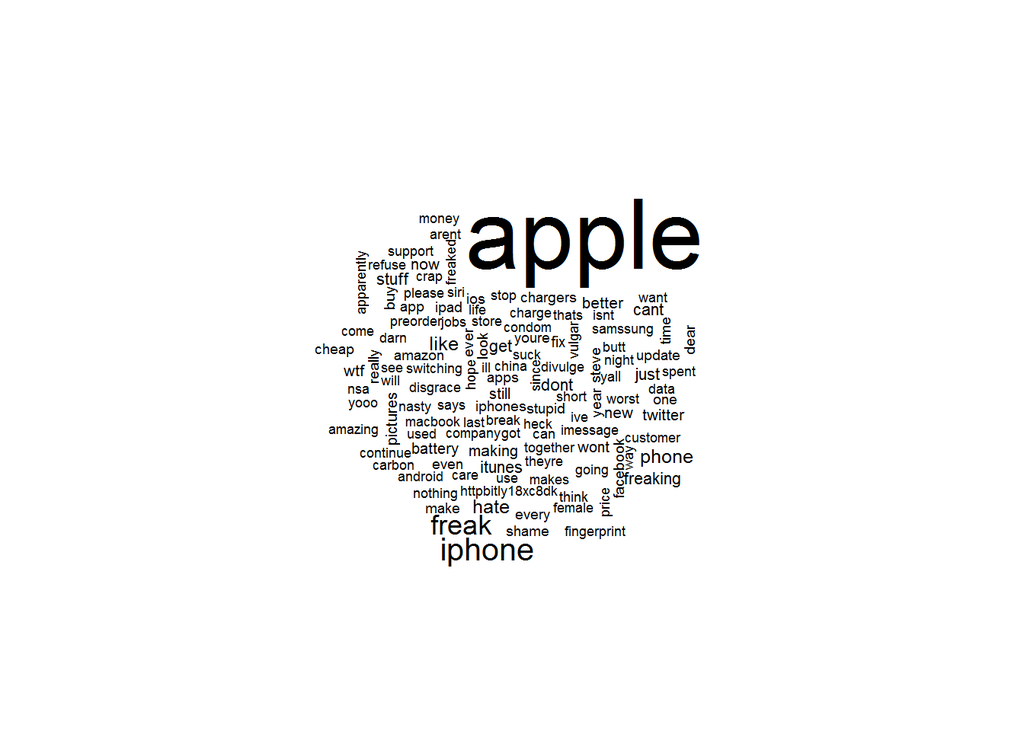

```r
negativeTweets = subset(allTweets, tweets$Avg <= -1)

wordcloud(colnames(negativeTweets), colSums(negativeTweets))
```

Original Word cloud

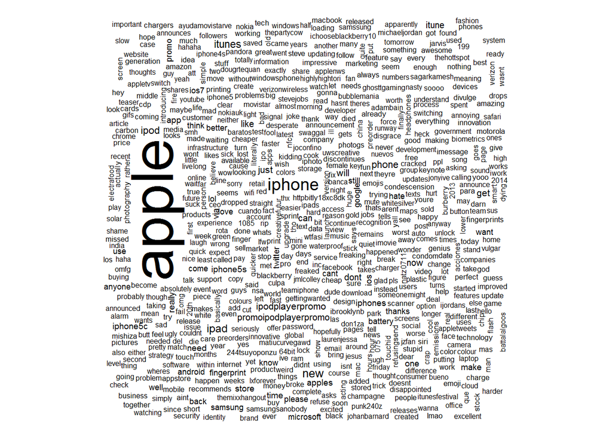

```r
wordcloud(colnames(allTweets), colSums(allTweets))
```

100 words

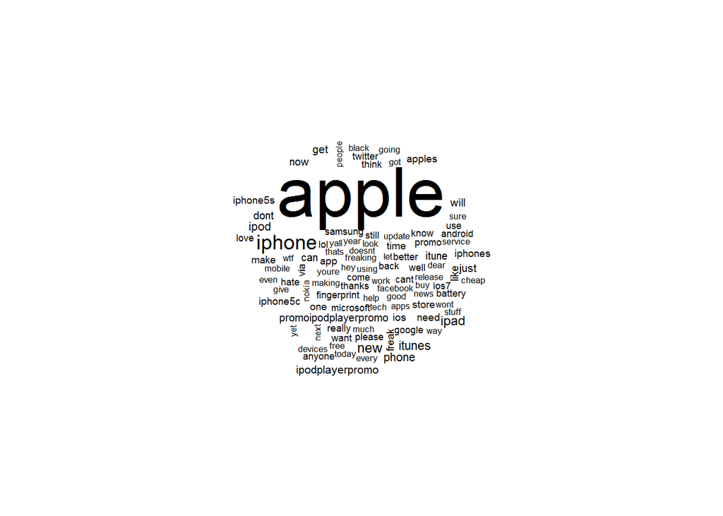

```r
wordcloud(colnames(allTweets), colSums(allTweets), max.words=100)
```

100 words and nonrandom order

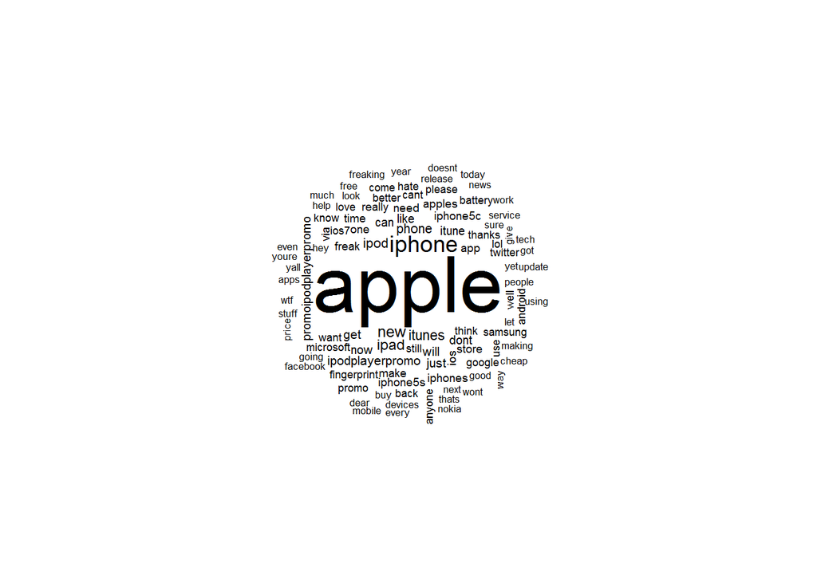

```r
wordcloud(colnames(allTweets), colSums(allTweets), max.words=100, random.order = F)
```

Note in above plot that setting `random.order` to `False` plots most frequent words toward the center of the word cloud.

Let’s now try changing the parameter `rot.per`. This is the proportion of words that’ll appear rotated 90 degrees in the word cloud.

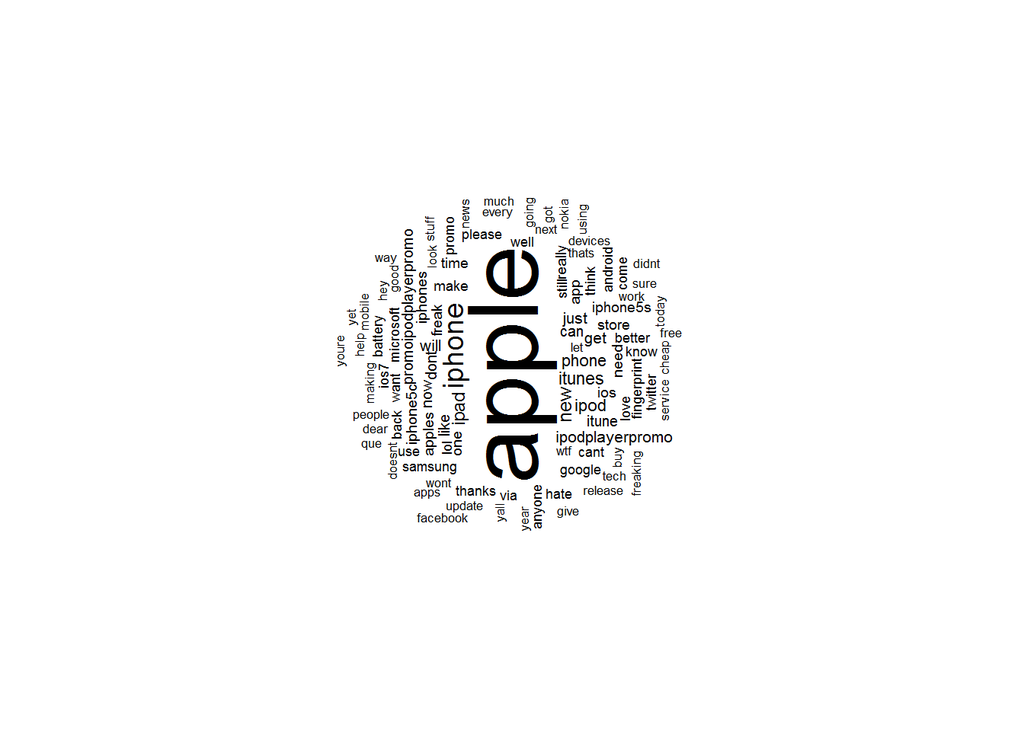

```r
wordcloud(colnames(allTweets), colSums(allTweets), max.words=100, random.order = F, rot.per = 0.5) #default value of rot.per is 0.10
```

### Problem 4

Display all color palettes available in pkg RColorBrewer

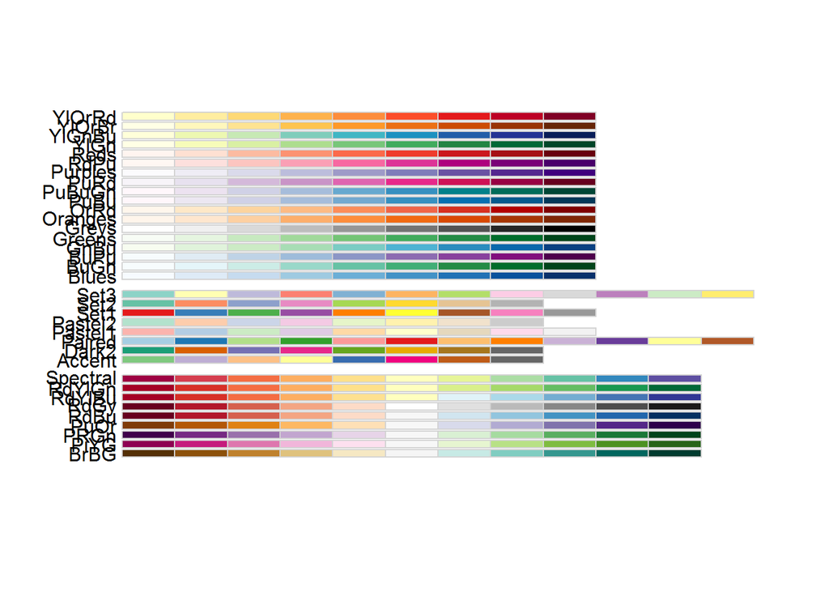

```r
display.brewer.all()
```

```r
colors=brewer.pal(9, "Blues")
colors
```

```
## [1] "#F7FBFF" "#DEEBF7" "#C6DBEF" "#9ECAE1" "#6BAED6" "#4292C6" "#2171B5"
## [8] "#08519C" "#08306B"
```

[figure not shown]

```r
wordcloud(colnames(allTweets), colSums(allTweets), max.words=100, random.order=F, colors=colors)
```

You can see in the above wordcloud that words that aren’t present in the tweets extremely frequently appear an extremely light shade of blue and thus are either barely visible or invisible.

The lightest shades are listed first in the vector, colors. We’ll remove the lightest 4 colors in the palette and then remake the wordcloud using the abridged palette.

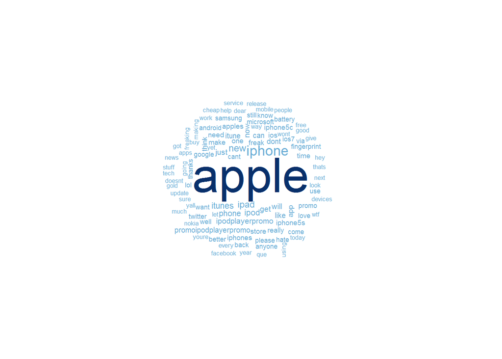

```r
darkColors = colors[5:9]
wordcloud(colnames(allTweets), colSums(allTweets), max.words=100, random.order=F, colors=darkColors)
```

## Visualizing attributes of parole violators

```r
parole=read.csv('parole.csv')
parole%>%head
```

```
##   male race  age state time.served max.sentence multiple.offenses crime
## 1    1    1 33.2     1         5.5           18                 0     4
## 2    0    1 39.7     1         5.4           12                 0     3
## 3    1    2 29.5     1         5.6           12                 0     3
## 4    1    1 22.4     1         5.7           18                 0     1
## 5    1    2 21.6     1         5.4           12                 0     1
## 6    1    2 46.7     1         6.0           18                 0     4
##   violator
## 1        0
## 2        0
## 3        0
## 4        0
## 5        0
## 6        0
```

### Problem 1

```r
parole$male = as.factor(parole$male)
parole$state = as.factor(parole$state)
parole$crime = as.factor(parole$crime)
head(parole)
```

```
##   male race  age state time.served max.sentence multiple.offenses crime
## 1    1    1 33.2     1         5.5           18                 0     4
## 2    0    1 39.7     1         5.4           12                 0     3
## 3    1    2 29.5     1         5.6           12                 0     3
## 4    1    1 22.4     1         5.7           18                 0     1
## 5    1    2 21.6     1         5.4           12                 0     1
## 6    1    2 46.7     1         6.0           18                 0     4
##   violator
## 1        0
## 2        0
## 3        0
## 4        0
## 5        0
## 6        0
```

```r
table(parole$male, parole$violator)
```

```
##
##       0   1
##   0 116  14
##   1 481  64
```

```r
table(parole$crime, parole$state)
```

```
##
##       1   2   3   4
##   1  66  42  42 165
##   2   9  10  15  72
##   3  34  64  20  35
##   4  34   4   5  58
```

### Problem 2

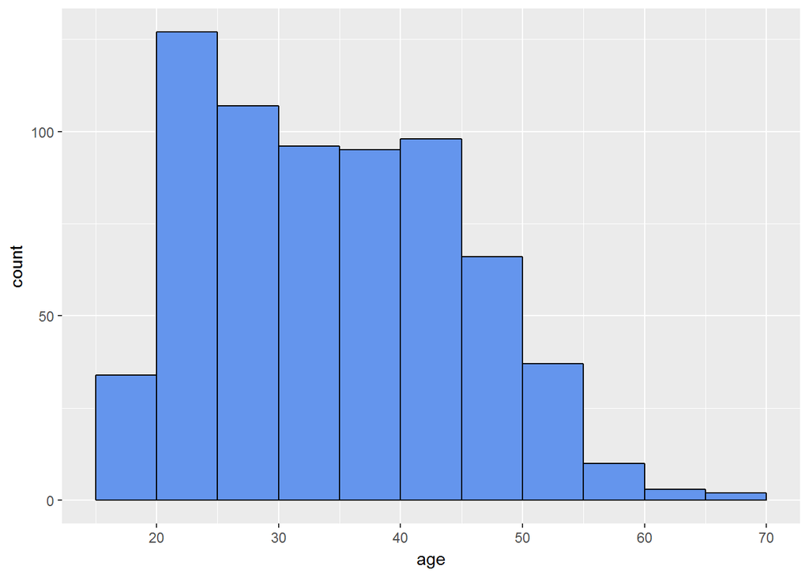

```r
ggplot(data = parole, aes(x = age)) + geom_histogram(binwidth = 5, boundary = 0, color = 'black', fill = 'cornflowerblue')
```

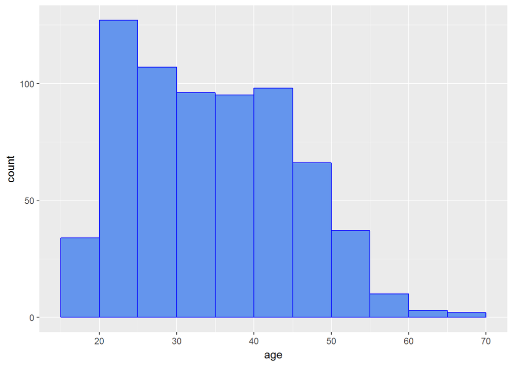

```r
ggplot(data = parole, aes(x = age)) + geom_histogram(binwidth = 5, boundary = 0, color = 'blue', fill = 'cornflowerblue')
```

### Problem 3

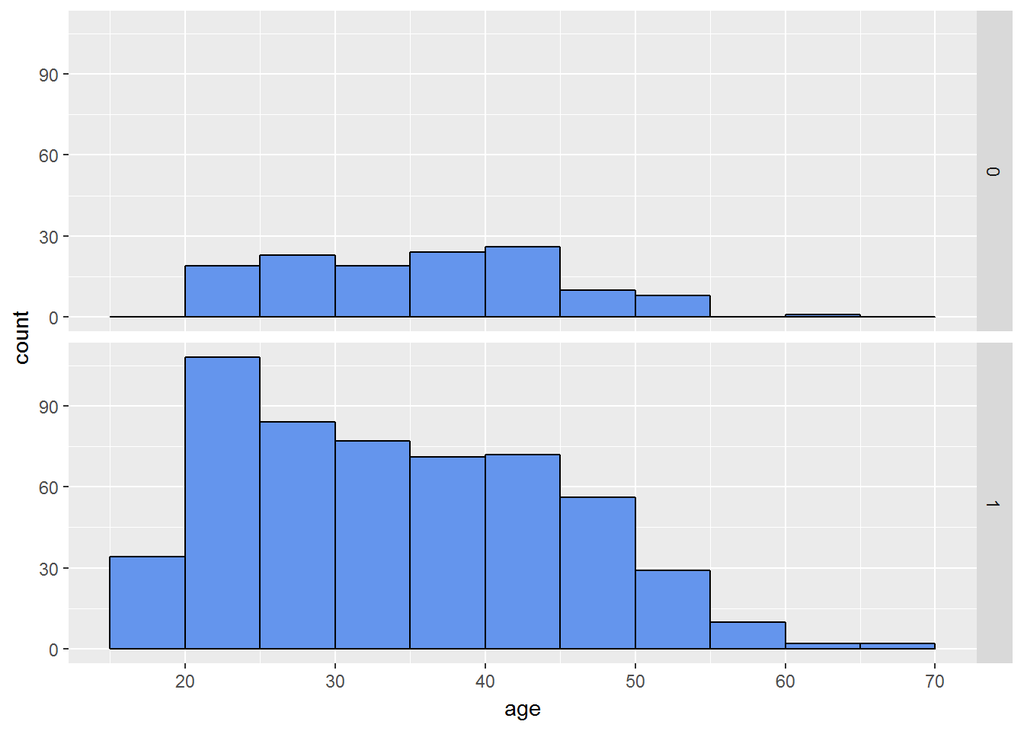

```r
ggplot(data = parole, aes(x = age)) + geom_histogram(binwidth = 5, boundary = 0, color='black',fill='cornflowerblue') + facet_grid(male ~ .)
```

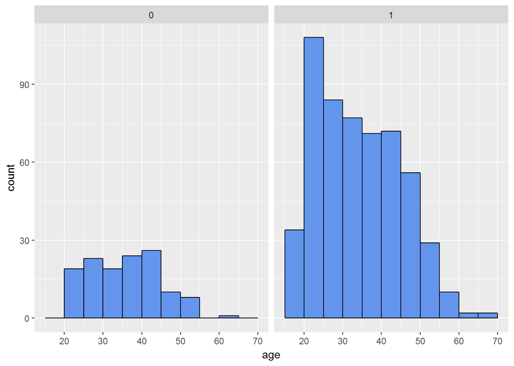

```r
ggplot(data = parole, aes(x = age)) + geom_histogram(binwidth = 5, boundary = 0, color='black',fill='cornflowerblue') + facet_grid(. ~ male)
```

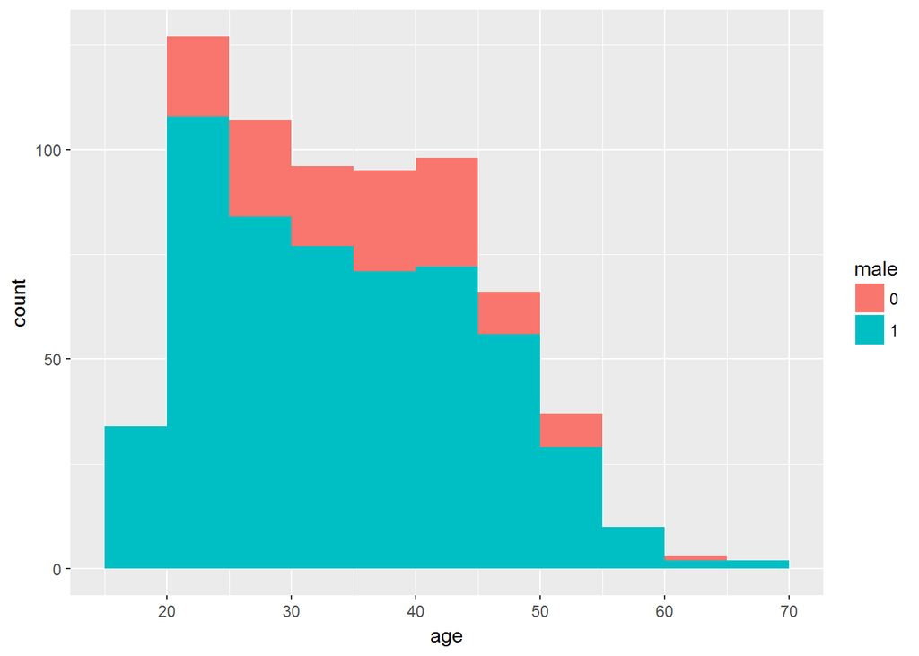

```r
ggplot(data = parole, aes(x = age, fill = male)) + geom_histogram(binwidth = 5, boundary = 0)
```

In above plot, default colors are used since no colors are specified.

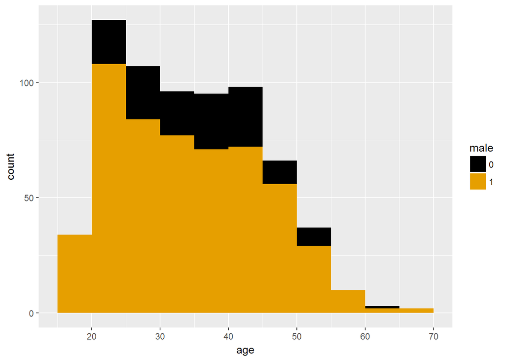

```r
colorPalette = c("#000000", "#E69F00", "#56B4E9", "#009E73", "#F0E442", "#0072B2", "#D55E00", "#CC79A7")
ggplot(data = parole, aes(x = age, fill = male)) + geom_histogram(binwidth = 5, boundary = 0) + scale_fill_manual(values=colorPalette)
```

Let’s remake the above plot, but make the bars overlaid rather than stacked.

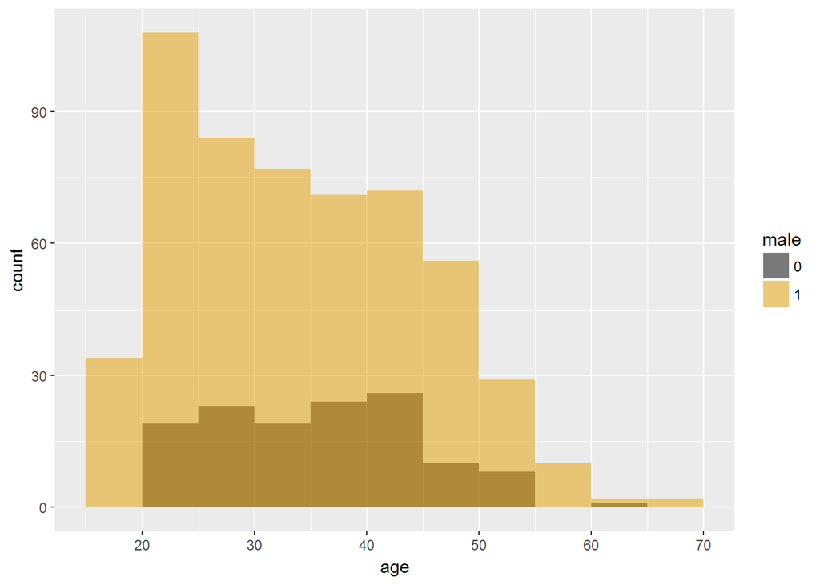

```r
ggplot(data = parole, aes(x = age, fill = male)) + geom_histogram(binwidth = 5, boundary = 0, position='identity', alpha=0.5) + scale_fill_manual(values=colorPalette)
```